# GEOG 215: Final Project

Hari Potharaju

2023-07-28

```r
# Loading necessary libraries

library(tidyverse)
library(sf)
library(tmap)
library(knitr)
library(kableExtra)
library(shinyjs)
library(spdep)
library(spatstat)
library(maptools)
```

## Introduction

In this project, I am conducting spatial data analysis on census data from the American Community Survey performed in the year 2021. My variable of interest is income (in the past 12 months) below the poverty level for white populations alone. My normalization variable is all income for white populations alone. The spatial scope for this analysis is North Carolina counties.

## Data Preparation

```r
# Read in Income Below Poverty Level data from the data file

inc_bel_pov <- st_read("../Data/In_bel_pl2.shp",
                        quiet = TRUE)
```

In order to acquire the necessary data for my analysis I had to obtain an API key with which I was able to gain access to the raw census data and extract my data of interest. Additionally, in order to normalize my census data, I created a new column with the percentage of white populations with an income under the poverty level per county. After preparing my tabular census data, I then acquired my spatial data at the North Carolina county level which I later used to execute a spatial join between my two data frames.

## Exploratory Spatial Data Analysis

### Data Description and Summary

```r
n.obs <- nrow(inc_bel_pov)         # Obtaining number of rows/observations
na.obs <- sum(is.na(inc_bel_pov$percent))   # Obtaining number of NA rows/observations
min.obs <- min(inc_bel_pov$percent, na.rm = TRUE) # Obtaining minimum
max.obs <- max(inc_bel_pov$percent, na.rm = TRUE) # Obtaining maximum
mean.obs <- mean(inc_bel_pov$percent, na.rm = TRUE) # Obtaining mean
sd.obs <- sd(inc_bel_pov$percent, na.rm = TRUE)  # Obtaining standard deviation

# Creating a summary table of descriptive statistics for my variable of interest

summary.table <- tibble(Measure = c("Number of Observations",  # Labeling measure column
                                    "Number of NA",
                                    "Minimum",
                                    "Maximum",
                                    "Mean",
                                    "Standard Deviation"),
                        `Percentage` = c(n.obs,              # number of rows/observations
                                       na.obs,  # number of NA rows/observations
                                       min.obs, #  minimum
                                       max.obs, #  maximum
                                       mean.obs, #  mean
                                       sd.obs  #  standard deviation
                                       ),
                        )


# Printing a nicer version of the table using Kable

kable(summary.table,
      digits = 2,
      format.args = list(big.mark = ",",
                         scientific = FALSE,
                         drop0trailing = TRUE),
      caption = "Summarizing Rate Of White Population In North Carolina With Income Under The Poverty Level (by county)") %>%   #Naming the table
  kable_styling(bootstrap_options = c("striped",
                                      "hover",
                                      "condensed",
                                      "responsive"),
                full_width = F)
```

Summarizing Rate Of White Population In North Carolina With Income Under The Poverty Level (by county)

| Measure | Percentage |
| --- | --- |
| Number of Observations | 100 |
| Number of NA | 0 |
| Minimum | 5.35 |
| Maximum | 22.24 |
| Mean | 12.14 |
| Standard Deviation | 3.4 |

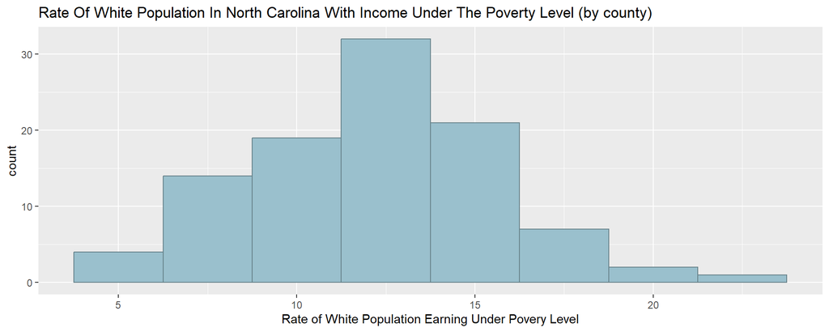

```r
# Ploting the histogram

ggplot(inc_bel_pov, # Data
       aes(x = percent)) + # Column used
  geom_histogram(binwidth = 2.5, colour = "lightblue4", fill = "lightblue3") +    # Choosing bin width and color
  xlab("Rate of White Population Earning Under Povery Level") +    # X-axis label
  ggtitle("Rate Of White Population In North Carolina With Income Under The Poverty Level (by county)") # Title of graph
```

The number of observations is 100 of which 0 values have NA observations which means all one hundred counties have an assigned percentage of white population earning under the poverty level. There is a fairly large range with the lowest county only having a percentage of around 5.35 and the highest county having a percentage of 22.24 which is a 16.89 percent difference. The mean falls at around 12.136 percent. The data has a standard deviation at 3.4 which is not very high but still shows that there is some variation between counties.

I learned that my data is normally distributed, which essentially means that most data points cluster toward the middle of the range, while the rest taper off symmetrically toward either extreme. This means that there are mostly no extreme outliars and the variation of my data set is relatively low. I came to this conclusion because the histogram appears to be a bell curve which is a graphical depiction of a normal distribution. Additionally, the ranges from ~ 11.5 to ~ 14.5 have the highest count at a little more then 30 which signifying that the mean actually falls in-between this range this shows that the mean is fairly accurate and the data is not greatly skewed by outliars.

### Geographic Distribution and Spatial Clustering

```r
# Changing the color of the background map

tmap_options (bg.color = "#C696CE", basemaps.alpha = .7)

# Making maps interactive

tmap_mode("view")

# Creating a choropleth using the percentage variable of the white population earning under the poverty level

choropleth_map <- tm_shape(inc_bel_pov) + tm_polygons("percent",
              style = "jenks",
              palette = "BuPu") +
  tm_layout (frame = FALSE, bg.color = "#C696CE")

## Create Queen case neighbors

ibp.nb.queen <- poly2nb(inc_bel_pov,
                           queen = TRUE)

## Convert neighbor object to weight matrix

ibp.w.queen <-  nb2listw(ibp.nb.queen,
                            style = "B",         # B is binary (1,0)
                            zero.policy = TRUE)  # Allow obs with 0 neighbors

# Moran's I

ibp.moran <- moran.test(inc_bel_pov$percent,       # Data we're analyzing
                           ibp.w.queen,            # Sp weights matrix
                           randomisation = TRUE,   # Compare to randomized values
                           zero.policy = TRUE)     # Allow obs with 0 neighbors

## Summary

ibp.moran
```

```
##
##  Moran I test under randomisation
##
## data:  inc_bel_pov$percent
## weights: ibp.w.queen
##
## Moran I statistic standard deviate = 5, p-value = 2e-06
## alternative hypothesis: greater
## sample estimates:
## Moran I statistic       Expectation          Variance
##           0.27394          -0.01010           0.00384
```

```r
# LISA -- Local Moran's I

ibp.lisa <- localmoran(inc_bel_pov$percent,        # The column in your sp data
                          ibp.w.queen,             # Weights object
                          zero.policy = TRUE) %>%  # Best to keep TRUE for LISA
  as.data.frame()         # Make result into data frame

# Scale the input data to deviation from mean

cDV <- inc_bel_pov$percent - mean(inc_bel_pov$percent)

# Get spatial lag values for each observation
# These are the neighbors' values

lagDV <- lag.listw(ibp.w.queen, inc_bel_pov$percent)

# Scale the lag values to deviation from mean

clagDV <- lagDV - mean(lagDV, na.rm = TRUE)

# Add holder column with all 0s

ibp.lisa$Cat <- rep("0", nrow(ibp.lisa))

# This simply adds a label based on the values

ibp.lisa$Cat[which(cDV > 0 & clagDV > 0 & ibp.lisa[,5] < 0.05)] <- "HH"
ibp.lisa$Cat[which(cDV < 0 & clagDV < 0 & ibp.lisa[,5] < 0.05)] <- "LL"
ibp.lisa$Cat[which(cDV < 0 & clagDV > 0 & ibp.lisa[,5] < 0.05)] <- "LH"
ibp.lisa$Cat[which(cDV > 0 & clagDV < 0 & ibp.lisa[,5] < 0.05)] <- "HL"

# Quick SUMMARY of LISA output

table(ibp.lisa$Cat)
```

```
##
##  0 HH HL LH LL
## 87  3  1  1  8
```

```r
## Add LISA category column to the spatial data for mapping

inc_bel_pov$LISACAT <- ibp.lisa$Cat

# Second the LISA map

lisa.tmap <- tm_shape(inc_bel_pov) +
  tm_polygons("LISACAT",
              title = "LISA Category",
              style = "cat",
              palette = c("0" = "grey",
                          "HH" = "purple3",
                        "HL" = "lavender",
                          "LL" = "blue",
                          "LH" = "lightblue"),
              border.col = "Black",
              border.alpha = 0.25) +
  tm_layout (frame = FALSE, bg.color = "#C696CE")

# Mapping the two maps together

tmap_arrange(choropleth_map, lisa.tmap)
```

[interactive chart not shown]

When looking at the choropleth map, the first observation regarding the geographic variation that I made was that it appears to be in clusters. I see sporadic groups of counties that have higher rates of white populations with an income less then the poverty level. Specifically I see a large cluster in the far left mountain region and a belt of counties going up the inner coastal plain region.

The Moran I test evaluates whether an expressed pattern is clustered, dispersed, or random mathematically as opposed to visually like I did with the choropleth map. In this case there was a Moran I statistic of ~ .27394 which indicates that there is a pattern of clustering present in the data however because the output is fairly low this indicates that there is only slight clustering. Additionally, the p-value is incredibly low which indicates that the results of the test are significant or in other words the likelihood that the results are due to chance are very low.

The LISA results show that there are areas of the map that have some clustering, there is mostly low-low clustering which means that observations with low values are surrounded with neighbors that also have low values. While the results show that there is definitely some clustering, as the Moran I test previously indicated, there is only slight clustering. A majority of the map is filled with grey space which shows that those areas don’t have a significant pattern or any form of clustering.

## Conclusion

In conclusion, throughout this data analysis, I came to an understanding that the percentage of white population in North Carolina who earn an income under the poverty level is not drastically concentrated in specific counties and is spread out in a fairly normal distribution. However, with that being said there is evidence that some areas of North Carolina have clustering - the most common of which is areas with low rates of white population in poverty are surrounded by other counties who also have low rates of white population in poverty.

## Document Statistics

| Method | koRpus | stringi |
| --- | --- | --- |
| Word count | 724 | 716 |
| Character count | 4316 | 4316 |
| Sentence count | 29 | Not available |
| Reading time | 3.6 minutes | 3.6 minutes |